# Aula 4 - Séries Temporais

Autor

João Ricardo F. de Lima

Data de Publicação

5 de junho de 2025

# Estimação da Tendência e da Taxa de Crescimento

## Estimação de Tendências Determinística

Uma **Série Temporal** é qualquer conjunto de dados ordenados no tempo, com cada valor associado a um instante de tempo.

O enfoque clássico do estudo de séries temporais busca decompor a série em quatro componentes:

1. Tendencia (T): Componente da série que possui movimento contínuo, para cima ou baixo, por um período longo de tempo;
2. Ciclo (C): Componente que apresenta movimento oscilatório ao longo da tendência durante um período de tempo maior do que um ano, nao necessariamente regular;
3. Sazonalidade: Componente que apresenta movimento oscilatório que ocorre com regularidade em subperíodos de um período de tempo fixo;
4. Volatilidade (I): Componente aleatório.

A **Tendência determinística** de uma série temporal é representada por mudanças no nível médio da série que ocorrem de forma previsível, em função do tempo.

Existem vários métodos para estimar a tendência determinística $T_t$. Os mais utilizados são os métodos de regressão e os de média móvel.

No método de regressão, ajusta-se $Y_t$ como uma função do tempo:

$$Y_t=f(t)+\epsilon_t$$

em que f(t) pode assumir a forma de um polinômio de qualquer grau ou exponencial. Tem-se as seguintes possibilidades:

1. Tendência Linear: $Y_t=\beta_0+\beta_1t+\epsilon_t$
2. Tendência Quadrática: $Y_t=\beta_0+\beta_1t+\beta_2t^2+\epsilon_t$
3. Polinômio de grau k: $Y_t=\beta_0+\beta_1t+\beta_2t^2+\dots+\beta_kt^k+\epsilon_t$
4. Exponencial: $Y_t=Ae^{\beta t}\epsilon_t$

a variável explicativa nestes modelos é o tempo (t) que assume os valores t=1,2,3,…T, chamada de variável tendência (trend).

### Análise no Python

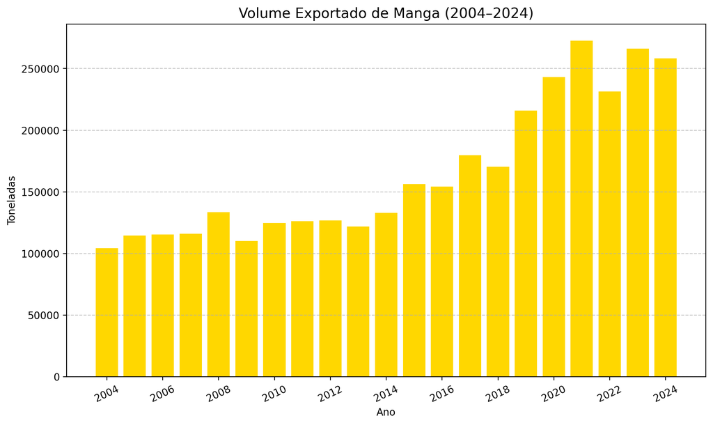

```python
import pandas as pd
import numpy as np
import statsmodels.formula.api as smf
import matplotlib.pyplot as plt

# Inserindo os dados
dados = pd.DataFrame({
    'ano': list(range(2004, 2025)),
    'toneladas': [104423, 114537, 115387, 116020, 133703,
    110194, 124671, 126124, 126917, 121943,
    133033, 156314, 154211, 179601, 170463,
    215834, 243226, 272560, 231364, 266098,
    258305],
    'tendencia': range(1,22)
})

# Gráfico de barras
plt.figure(figsize=(10, 6))
# Mostrar os anos de 2 em 2 no eixo X
anos_exibir = list(range(2004, 2025, 2))
plt.bar(dados['ano'], dados['toneladas'], color='gold')
plt.title('Volume Exportado de Manga (2004–2024)', fontsize=14)
plt.xlabel('Ano')
plt.ylabel('Toneladas')
plt.grid(axis='y', linestyle='--', alpha=0.7)
plt.xticks(rotation=25)
plt.xticks(anos_exibir)
plt.tight_layout()
plt.show()
```

```python
# Estimação do modelo
modelo1 = smf.ols('toneladas ~ tendencia', data=dados).fit()
print(modelo1.summary())
```

```
                            OLS Regression Results
==============================================================================
Dep. Variable:              toneladas   R-squared:                       0.836
Model:                            OLS   Adj. R-squared:                  0.827
Method:                 Least Squares   F-statistic:                     96.64
Date:                Thu, 05 Jun 2025   Prob (F-statistic):           6.93e-09
Time:                        10:59:59   Log-Likelihood:                -240.54
No. Observations:                  21   AIC:                             485.1
Df Residuals:                      19   BIC:                             487.2
Df Model:                           1
Covariance Type:            nonrobust
==============================================================================
                 coef    std err          t      P>|t|      [0.025      0.975]
------------------------------------------------------------------------------
Intercept   7.198e+04   1.09e+04      6.631      0.000    4.93e+04    9.47e+04
tendencia   8499.1701    864.567      9.831      0.000    6689.611    1.03e+04
==============================================================================
Omnibus:                        1.542   Durbin-Watson:                   0.738
Prob(Omnibus):                  0.462   Jarque-Bera (JB):                0.978
Skew:                           0.161   Prob(JB):                        0.613
Kurtosis:                       1.993   Cond. No.                         26.2
==============================================================================

Notes:
[1] Standard Errors assume that the covariance matrix of the errors is correctly specified.
```

## Estimação de Taxa de Crescimento

Como calcular Taxa de Crescimento? Sempre estamos interessados em conhecer taxas de crescimento: a) Lucro; b) Custos; c) População; d) Emprego; e) Exportações, etc.

Para isto, usando a fórmula

$$Y_t=Y_0{(1+r)^t}$$

$y_t$ é a variável a qual se deseja calcular a taxa de crescimento; $y_0$ é o valor inicial da variável; t é o tempo; r é a taxa de crescimento ao longo do tempo de Y;

Tomando o logaritmo da equação, tem-se

$$ln Y_t=ln Y_0 +tln(1+r)$$

denominando

$\beta_0 = ln Y_0$

e

$\beta_1 = ln (1+r)$, reescreve-se a equação para;

$$ln Y_t=\beta_0 +\beta_1t$$

na forma de modelo de regressão

$$ln Y_t=\beta_0 +\beta_1t +u$$

com t assumindo os valores 1,2,3, etc..

Para se calcular a taxa de crescimento ao longo do tempo, deve-se aplicar a fórmula

$$[exp(\hat{\beta_1})-1]100$$

### Análise no Python

```python
import pandas as pd
import numpy as np
import statsmodels.formula.api as smf

# Inserindo os dados
dados = pd.DataFrame({
    'ano': list(range(2004, 2025)),
    'toneladas': [104423, 114537, 115387, 116020, 133703,
    110194, 124671, 126124, 126917, 121943,
    133033, 156314, 154211, 179601, 170463,
    215834, 243226, 272560, 231364, 266098,
    258305],
    'tendencia': range(1,22)
})

# Estimação do modelo
modelo2 = smf.ols('np.log(toneladas) ~ tendencia', data=dados).fit()
print(modelo2.summary())
```

```
                            OLS Regression Results
==============================================================================
Dep. Variable:      np.log(toneladas)   R-squared:                       0.880
Model:                            OLS   Adj. R-squared:                  0.874
Method:                 Least Squares   F-statistic:                     140.0
Date:                Thu, 05 Jun 2025   Prob (F-statistic):           3.29e-10
Time:                        10:59:59   Log-Likelihood:                 16.488
No. Observations:                  21   AIC:                            -28.98
Df Residuals:                      19   BIC:                            -26.89
Df Model:                           1
Covariance Type:            nonrobust
==============================================================================
                 coef    std err          t      P>|t|      [0.025      0.975]
------------------------------------------------------------------------------
Intercept     11.4192      0.052    217.523      0.000      11.309      11.529
tendencia      0.0495      0.004     11.832      0.000       0.041       0.058
==============================================================================
Omnibus:                        1.533   Durbin-Watson:                   0.909
Prob(Omnibus):                  0.465   Jarque-Bera (JB):                0.922
Skew:                          -0.011   Prob(JB):                        0.631
Kurtosis:                       1.974   Cond. No.                         26.2
==============================================================================

Notes:
[1] Standard Errors assume that the covariance matrix of the errors is correctly specified.
```

### Cálculo da Taxa de Crescimento Geométrica

```python
# Coeficiente da tendência
beta1 = modelo2.params['tendencia']

# Cálculo da taxa geométrica de crescimento em %
taxa_geom_percentual = (np.exp(beta1) - 1) * 100

# Exibir a frase com o valor formatado
print(f"O valor calculado da taxa geométrica de crescimento é: {taxa_geom_percentual:.2f}% ao ano.")
```

```
O valor calculado da taxa geométrica de crescimento é: 5.07% ao ano.
```